# Untitled

Trent Meyer

2022-10-06

```r
library(tidyverse)
wc_forecasts <- read_csv("data/world-cup-2018/wc_forecasts.csv")
wc_matches <- read_csv("data/world-cup-2018/wc_matches.csv")
```

Given each team’s SPI rating, the process for generating win/loss/draw probabilities for a World Cup match is three-fold:

1. We calculate the number of goals that we expect each team to score during the match. These projected match scores represent the number of goals that each team would need to score to keep its offensive rating exactly the same as it was going into the match.
2. Using our projected match scores and the assumption that goal scoring in soccer follows a Poisson process, which is essentially a way to model random events at a known rate, we generate two Poisson distributions around those scores. Those give us the likelihood that each team will score no goals, one goal, two goals, etc.

# Russia

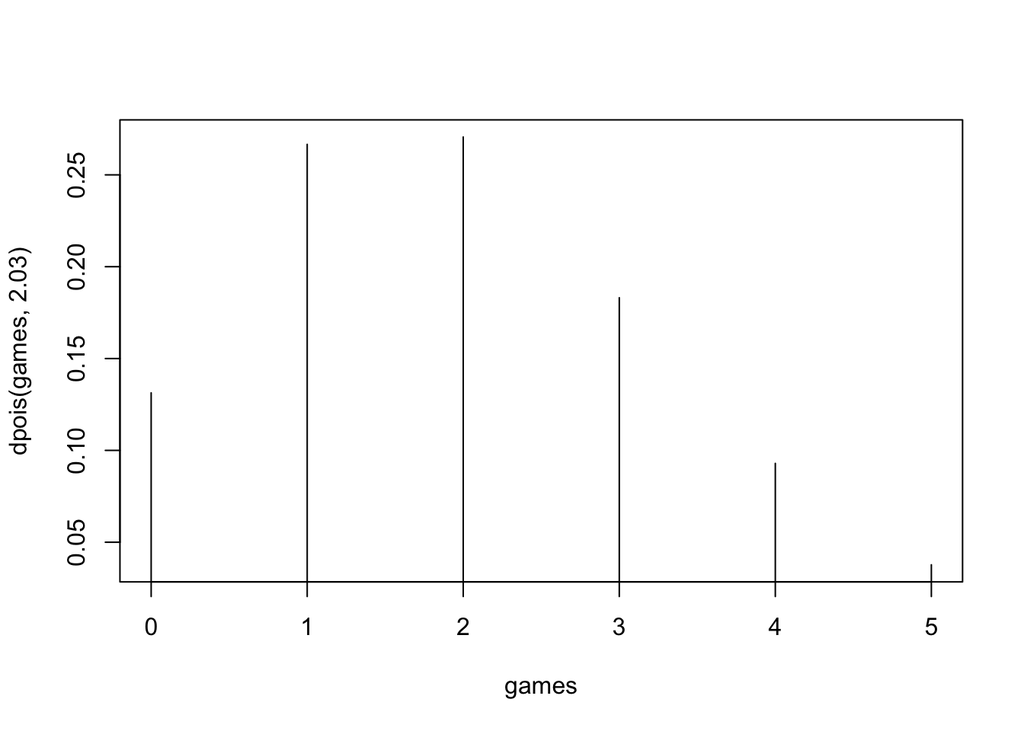

```r
games <- 0:5
plot(games, dpois(games, 2.03), type = "h")
```

```r
russiawin <- dpois(games, 2.03)
```

# Saudi Arabia

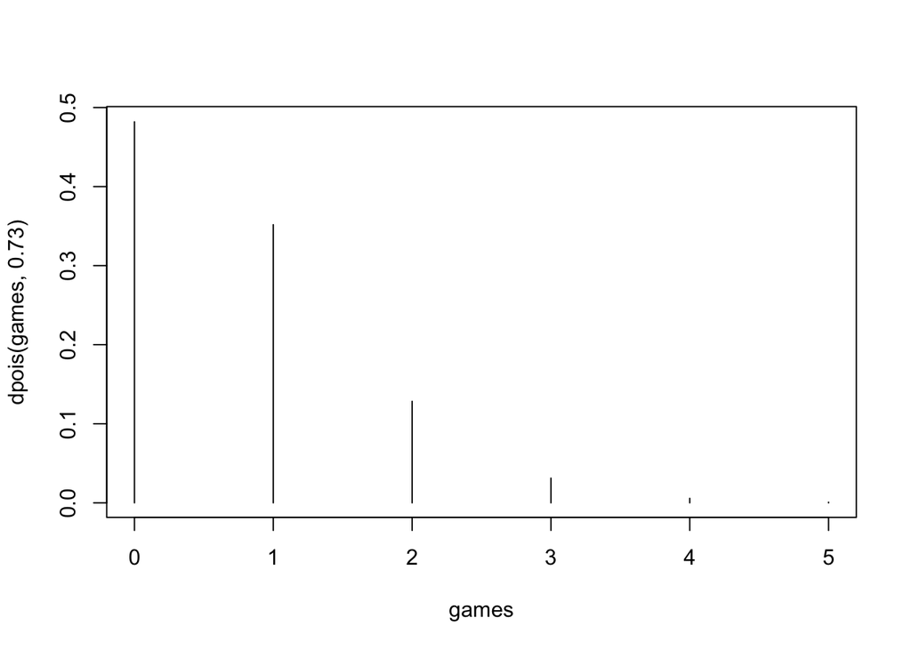

```r
plot(games, dpois(games, 0.73), type = "h")
```

```r
saudiwin <- dpois(games, 0.73)
```

3. We take the two Poisson distributions and turn them into a matrix of all possible match scores from which we can calculate the likelihood of a win, loss or draw for each team. To avoid undercounting draws, we increase the corresponding probabilities in the matrix.

```r
# predicting the probabilities that Russia will score 0:5 goals
russiawin <- dpois(0:5, wc_matches$proj_score1[1])

# predicting the probabilities that Saudi Arabia will score 0:5 goals
saudiwin <- dpois(0:5, wc_matches$proj_score2[1])
```

```r
# Turning the probabilities into matrices
russiamatrix <- matrix(russiawin, nrow = 1, ncol = 6)
saudimatrix <- matrix(saudiwin, nrow = 6, ncol = 1)

# Multiplying the matrices to get a 6x6 matrix with probabilities
# that each team will score that amount of goals, from which
# we can get the probability that each team will win
probmatrix <- saudimatrix %*% russiamatrix

# I transposed this because using as.vector went down the columns, except I wanted
# to go across the rows first
probmatrix_t <- t(probmatrix)

# With the transposed matrix, I wanted to create a vector, and then use cumsum()
# to get the cumulative sum
probvector <- as.vector(probmatrix, mode = "numeric")
cumprob <- cumsum(probvector)

# generate a random uniform value
prob_index <- runif(1, 0, 1)

# find out which values fall above that probability
which_index <- which(cumprob >= prob_index)

# single out the first index, and determine if that would be a win, loss, or draw,
# and for which team
index_sim <- which_index[1]
```